[figure not shown]

[figure not shown]

User's Guide for Toolkit

Developers

Scope of this Manual

The User's Guide for Toolkit Developers provides detailed information

about the design of Geant4 classes as well as the information required to

extend the current functionality of the Geant4 toolkit. This manual is

designed to:

provide a repository of information for those who want to understand

or refer to the detailed design of the toolkit, and

provide details and procedures for extending the functionality of the

toolkit so that experienced users may contribute code which is

consistent with the overall design of Geant4.

This manual is intended for developers and experienced users of Geant4. It

is assumed that the reader is already familiar with functionality of the

Geant4 toolkit as explained in the "User's Guide For Application

Developers", and also has a working knowledge of programming using

C++. A knowledge of object-oriented analysis and design will also be

useful in understanding this manual. It is also useful to consult the

"Software Reference Manual" which provides a list of Geant4 classes and

their major methods.

Detailed discussions of the physics included in Geant4 are provided in the

"Physics Reference Manual".

Contents

Introduction

Design and Function of Geant4 Categories

Extending Toolkit Functionality

Bibliography

[figure not shown]

Status of this Document

Guide for developers of the Geant4 toolkit.

Rev 1.0: First Sphinx version implemented for Geant4 Release

10.4, 8th Dec 2017

Rev 2.0: Updates and fixes in documentatio for Geant4 Release

10.4, 15th May 2018

Rev 3.0: Geant4 Release 10.5, 11th December 2018

Rev 3.1: Geant4 Updates and fixes - especially to search functionality,

5th March 2019

Rev 4.0: Geant4 Release 10.6, 6th December 2019

Rev 5.0: Geant4 Release 10.7, 4th December 2020

Rev 6.0: Geant4 Release 11.0, 10th December 2021

Rev 7.0: Geant4 Release 11.1, 9th December 2022

Rev 7.1: Geant4 Fixes to http links, 15th July 2023

Rev 8.0: Geant4 Release 11.2, 8th December 2023

Rev 9.0: Geant4 Release 11.3, 6th December 2024

revision numbers to be in-phase with release

Footnotes

[figure not shown]

Introduction

Contents:

How to use this manual

User Requirements Document

Footnotes

[figure not shown]

How to use this manual

Part I: to understand the goal of the software design of Geant4, it is useful

to begin by reading the User Requirements Document referred to in the next

section.

Part II: "Design and Function of the Geant4 Categories" provides detailed

information about the design of each class category and the classes in it.

Before considering an extension of one of the toolkit categories, a detailed

understanding of that category is required.

Part III: :Extending Toolkit Functionality" explains in some detail how to

extend the functionality of Geant4. Most of the class categories are covered

and some, which are especially useful to most users, are covered in greater

detail.

It is not necessary to understand the entire manual before adding a new

functionality. To add a new physics process, for example, only the

following items must be read and understood:

the design principle described in the "Physics processes" chapter of

Part II

techniques explained in the "Physics processes" chapter of Part III.

Footnotes

[figure not shown]

[#1]

User Requirements Document

At the beginning of Geant4 development, a set of user requirements was

collected in order to inform the object-oriented analysis and design of the

toolkit. The User Requirements Document follows the PSS-05 software

engineering standards and is available at here[#1].

This document provides a general description of the main capabilities and

constraints of the toolkit. It also defines three types of users characterised

by their level of interaction with the system. Specific requirements are also

listed and classified.

Footnotes

https://geant4-userdoc.web.cern.ch/Notes/URD.pdf

[figure not shown]

Design and Function of Geant4

Categories

Contents:

Introduction

Run

Design Philosophy

Class Design

Event

Design Philosophy

Class Design

Tracking

Design Philosophy

Class Design

Track Category

Tracking Category

Tracking Algorithm

Interaction with Physics Processes

Ordering of Methods of Physics Processes

Physics Processes

Design Philosophy

Class Design

General

Electromagnetic

Hadronic

Hits and Digitisation

Design Philosophy

Class Design

Geometry

Design Philosophy

Class Design

Additional Geometry Diagrams

Electromagnetic Fields

[figure not shown]

Class Design

Particles

Design Philosophy

Class Design

Materials

Design Philosophy

Design

Classes For Material Description

The NIST Manager Utility

Optical Classes

Material Extension

Global Usage

Design Philosophy

Class Design

HEPNumerics

HEPGeometry

Design of Visualisation Category

Design Philosophy

The Graphics Interfaces

The Geant4 Visualisation System

Modelling sub-category

View parameters

Visualisation Attributes

Finding the applicable vis attributes

Intercoms

Design Philosophy

Class Design

Parallelism in Geant4: multi-threading capabilities

Event level parallelism

General Design

Memory handling in Geant4 Version 10.0

Introduction

Thread safety and sharing of objects

Details on the split classes mechanism

Explicit memory handling

Threading model utilities and functions

Types and functions related to the use of threads

[figure not shown]

Types and functions related to the use of mutexes and

conditions

Random Number Generation Seeding in MT

Additional material

Footnotes

Introduction

Geant4 exploits advanced software engineering techniques based on the

Booch/UML Object Oriented Methodology and follows the evolution of the

ESA Software Engineering Standards for the development process. The

"spiral", or iterative, approach has been adopted. User requirements were

collected in the initial phase and problem domain decomposition, object-

oriented methods, and CASE tools were used for analysis and design. This

produced a clear hierarchical structure of sub-domains linked by a uni-

directional flow of dependencies. This led to a software product which is

modular and flexible (a toolkit) and in which the physics implementation is

transparent and open to user validation of physics predictions. It allows the

user to understand, customise and extend the toolkit in all domains. At the

same time the modular architecture allows the user to load only needed

components.

Footnotes

Run

Design Philosophy

The run category manages collections of events (runs). In a single run the

events share the detector implementation, physics conditions and primary

generation.

The classes associated with the run category can be considered as the main

and higher level application programming interface (API) used in a Geant4

application. A simple application will use concrete classes provided with

the toolkit, the developer will provide the detector description a primary

generator (possibly using one of the general purpose ones provided with the

toolkit), define the physics for the application (the physics list, possibly one

of the few provided with the toolkit) and optional user actions to interact

with the simulation itself.

In few cases it is however necessary to modify the default behaviour of one

or more classes in this category to allow for a user-customisation. As an

example the class G4MTRunManager extends the basic run-manager

class to take into account event level parallelism via multi-threading.

During a run some states of the application are invariant and cannot be

modified: the physics list (i.e. the list of processes attached to each particle)

and the detector layout (note that some geometry primitives allow for

changing parameters during the event run: parameterisations. However

technically the class instances representing the detector layout do not

change during a run).

Class Design

The relevant classes for the run category are shown here. This show, in

particular, the relation between classes for the case of a multi-threaded

application. For a sequential application the diagram is simplified since no

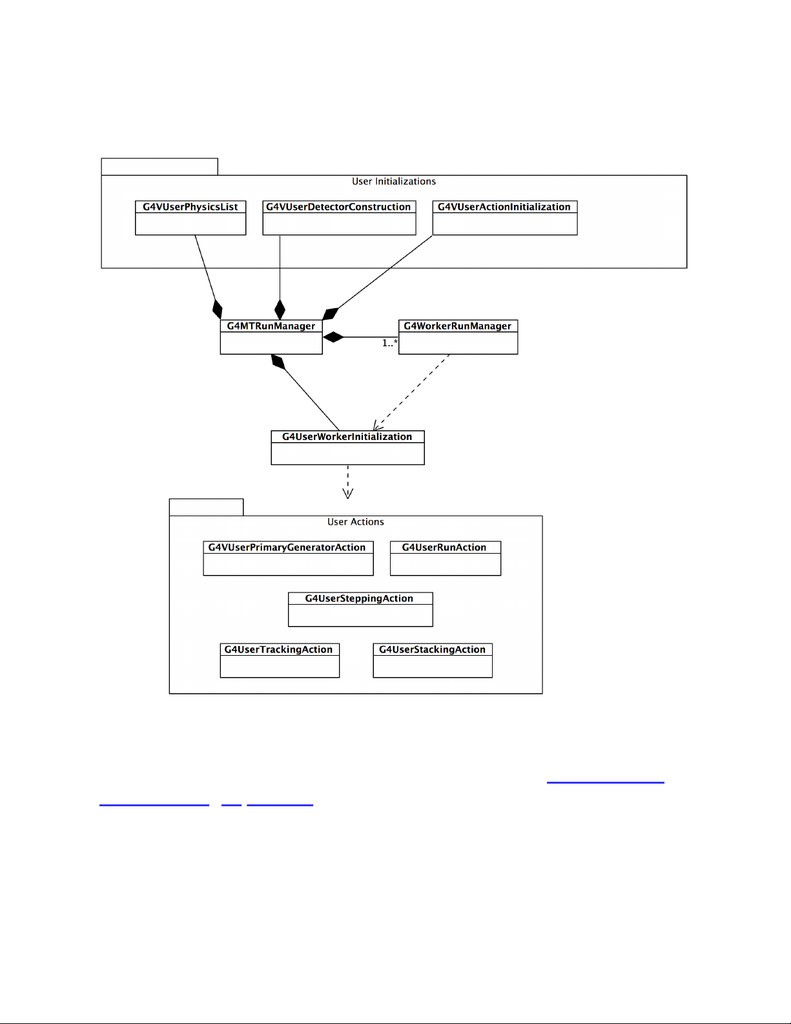

G4WorkerRunManager class exist and G4MTRunManager is replaced

by G4RunManager:

Fig. 1 Class diagram for main run category classes.

For a description of multi-threading functionality refer to Parallelism in :

multi-threading capabilities chapter.

One of the main functions of the run category is to control the life-cycle of

a Geant4 application, again with reference to the case of a multi-threaded

application the following schema describes it:

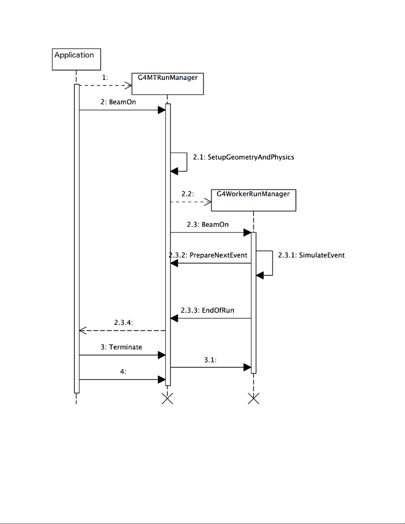

Fig. 2 Life cycle of a Geant4 application and main run category classes.

A list of the main classes for the category is provided:

[figure not shown]

G4Run - This class represents a run. An object of this class is

constructed and deleted by G4RunManager.

G4RunManager - the run controller class. Users must register

detector construction, physics list and primary generator action classes

to it. G4RunManager or a derived class must be a singleton. This class

provides several virtual methods that can be used to define user-

specific behaviour for a Geant4 application.

G4RunManagerKernel - provides control of the Geant4 kernel. This

class is constructed by G4RunManager. This class does not provide

virtual methods and user should not sub-class from it. The application

G4RunManager should own an instance of a G4RunManagerKernel

singleton.

G4{MT,Worker}RunManager[Kernel] - specialised versions to

provide a multi-threading enabled application. Refer to chapter

Parallelism in : multi-threading capabilities for additional information.

G4VUserDetectorConstruction - pure virtual base class that

represents the simulation setup.

G4VUserParallelWorld - pure virtual base class of the user's parallel

world.

G4VUserPhysicsList - pure virtual base class for a physics list.

G4VUserPrimaryGeneratorAction - pure virtual class used by user

to define the primary generation.

G4VModularPhysicsList - Pure virtual class to construct a physics

list from G4VPhysicsConstructor. More modern and modular

approach preferred in current versions of pre-packaged physics lists.

G4UserRunAction - user action class for run. Instantiate user-derived

G4Run and provides user-hooks for begin and end of run.

G4UserWorkerInitialization and

G4UserWorkerThreadInitialization - define here the concrete

behaviour for threading model. Both classes provide several virtual

methods that can be modified in derived classes.

G4VUserActionInitialization - pure virtual class used by user to

instantiate concrete instances of the user-actions.

G4WorkerThread - this class encapsulates thread-specific data.

G4RNGHelper - helper class to register and use RNG seeds. Used by

MT applications to guarantee reproducibility.

Footnotes

Event

Design Philosophy

In high energy physics the primary unit of an experimental run is an event.

The same concept is also known in other fields as history. We retain the

name from the HEP community. An event consists of a set of primary

particles, and a set of detector responses to these particles.

In Geant4, objects of the G4Event class are the primary units of a

simulation run. Before the event is processed, it contains primary vertices

and primary particles produced by a generator (a concrete implementation

of a G4VPrimaryGenerator). After the event is processed, it may also

contain hits, digitisations, and optionally, trajectories generated by the

simulation and additional user information (a sub-class of

G4VUserEventInformation). The event category manages events and

provides an abstract interface to the external generators.

G4Event and its content vertices and particles are independent of other

classes. This isolation allows Geant4-based simulation programs to be

independent of specific choices for physics generators and of specific

solutions for storing the "Monte Carlo truth". G4Event avoids keeping any

transient information which is not meaningful after event processing is

complete. Thus the user can store objects of this class for processing further

down the program chain. For performance reasons, G4Event and its content

classes are not persistent. Instead the user must provide the transient-to-

persistent conversion.

The current event being simulated is managed by G4EventManager, a

singleton responsible of handling the simulation of the event. The tracks

being followed for the current event are stored in a stack managed by

G4StackManager. Different stacks allow for fine control of the simulation

(urgent, waiting and postponed stacks).

[figure not shown]

User hooks allow for a customisation of the simulation behaviour via

G4UserEventAction, G4UserStackingAction and

G4VUserEventInformation.

Event generation is performed via a concrete implementation of a

G4VPrimaryGenerator class. This is usually instantiated by the user in the

user-defined concrete implementation of G4VUserPrimaryGeneratorAction

(belonging to the run category). Geant4 provides three concrete

implementation of G4VPrimaryGenerator: G4ParticleGun, a simple

generator that can shoot one or more primaries; G4HEPEvtInterface,

specifically designed for HEP experiments to read /HEPEVT/ common

block format; and the G4GeneralParticleSource able to generate primaries

distributed according to complex and configurable distributions. This last

possibility is described in detail in the Application Developers Guide.

Class Design

G4Event - this class represents an event. It is constructed and deleted

by G4RunManager or its derived class.

G4EventManager - this class controls an event. It must be a singleton

and should be constructed by G4RunManager.

G4TrajectoryContainer - this class can contain the concrete

G4VTrajectory objects defined by user or used to display the current

event.

G4UserEventAction - the abstract base class to allow for a user to

inject code at the beginning and end of an event.

G4UserStackingAction - the abstract base class to allow for the user

to control and tune the stacking of particles. See documentation in

class and Geant4 examples.

G4StackManager - controls the stacks of tracks belonging to the

event currently being processed. The three stacks are: urgent, waiting

and postponed. The first is of type G4SmartTrackStack while the other

two are of the simple G4TrackStack type.

G4VPrimaryGenerator - the abstract base class of all of primary

generators. This class has only one pure virtual method,

GeneratePrimaryVertex(), which takes a G4Event object, generates a

primary vertex and associates primary particles with the vertex.

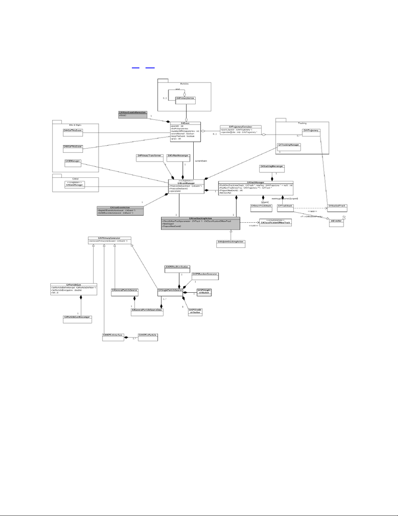

UML class diagrams for classes related to the event and event generator

classes are shown in Fig. 3.

Fig. 3 Event Category UML Diagram. Classes in grey are to be sub-classed

by user.

Footnotes

[figure not shown]

Tracking

In Geant4 the term 'tracking' means propagating a particle through a

geometrical structure. There are two class categories closely related each

other to describe the particle propagation:

tracking category: manages the contribution of the physics processes

to the evolution of a track's state and provides information in sensitive

volumes for hits and digitisation.

track category: represents physical information of a particle to be

propagated.

Design Philosophy

The tracking in Geant4 is based on step-wise propagation of the particle

through a given geometry. The overall performance of the Geant4

simulation depends critically on the CPU time spent to move the particle by

one step. Therefore the most important consideration in the object design of

the tracking and track categories is maintaining high execution speed of

step-wise propagation of the particle while utilising the power of the object-

oriented approach.

During the design stage of tracking two possible approaches were

investigated: 'single-class' versus 'structured-classes'. The 'single-class'

approach is based on a class design of mimicking a particle in the real

world. This approach looks object-oriented because a particle in the real

world propagates by itself while interacting with the material surrounding

it. The design would be to integrate all functionalities required for the

propagation of a particle into a single class, for example the 'particle class'.

Combining all the necessary functionalities into this single class exposes all

the data attributes to a large number of methods in the class. This is against

the strategy of 'data hiding', which is one of the most important ingredients

in the object-oriented approach.

[figure not shown]

The simulation of a particle passing through matter is a complex task

involving particles, detector geometry, physics interactions and hits in the

detector. In the 'structured-classes' approach the class design is based on the

idea of managing the complexity of the tracking task by separating it into

structured multiple classes. Object-oriented techniques, such as inheritance

and aggregation, play the essential roles in this design. In this approach it is

also possible to categorise the classes into multiple categories. This

approach enables each class category to be designed independently to

others.

The 'structured-classes' approach was employed for the tracking design

because it provides more flexibility in the designing and implementing

stages.

In order to maintain high-performance tracking, use of the inheritance ('is-a'

relation) hierarchy in the tracking and categories was avoided as much as

possible. For example, track and particle classes might have been

designed so that a track 'is a' particle. In this scheme, however, whenever

a track object is used, time is spent copying the data from the particle

object into the track object. Adopting the aggregation ('has-a' relation)

hierarchy requires only pointers to be copied, thus providing a performance

advantage.

Class Design

Track Category

The class diagram shown in Fig. 4 describes the static structure of classes in

the 'track' category and their relation to closely coupled classes. The design

is characterised by the hierarchic structure of three major classes, i.e.

G4Track, G4Step and G4StepPoint. Main features of these classes are

explained below.

G4Track represents a particle which is pushed by

G4SteppingManager. It holds information required for stepping a

particle, for example, the current position, the time since the start of

[figure not shown]

stepping, the identification of the geometrical volume which contains

the particle, etc.

Dynamic information, such as particle momentum and energy, is held

in the class through a pointer to the G4DynamicParticle class. Static

information, such as the particle mass and charge is stored in the

G4DynamicParticle class through the pointer to the

G4ParticleDefinition class. Here the aggregation hierarchical design

is extensively employed to maintain high tracking performance.

G4Track has information of the most recent step pushed by

G4SteppingManager as a G4Step object. For G4Step see the

explanation below.

G4Step keeps information of a step pushed by G4SteppingManager. It

holds information, for example, the step length and the deposited

energy during a step. Information related to the begin/end points of a

step are kept in the aggregated objects of G4StepPoint, which is

described below.

G4StepPoint keeps information of either the beginning or the end

points of a step. This includes the geometry position, the volume to

which the step point belongs, the global time when a step point is

created, the physics process which occurred at a step point, etc.

Two objects of G4StepPoint (PreStepPoint and PostStepPoint) are

aggregated by a step.

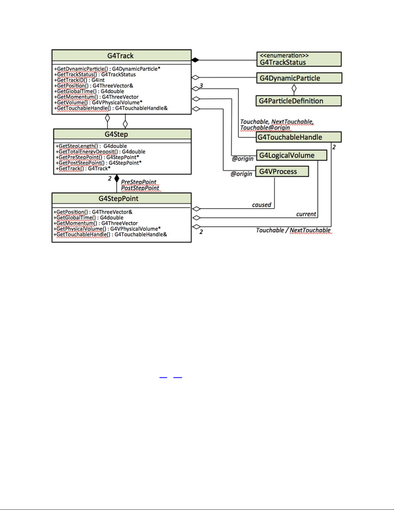

Fig. 4 Tracking design.

Tracking Category

As mentioned already the tracking in Geant4 is based on step-wise

propagation of the particle. The propagation is steered by two major classes

in the 'tracking' category - G4TrackingManager and G4SteppingManager.

G4TrackingManager propagates a particle from its start point to end.

G4SteppingManager steers a single step in the particle propagation.

design is characterised by the hierarchic structure of two major classes, i.e.

G4TrackingManager and G4SteppingManager. Main features of these

classes and their closely related ones are explained below.

G4TrackingManager

[figure not shown]

is responsible for processing one track passed from the event manager

G4EventManager. G4EventManager belongs to the event class category

and is the hierarchically upper manager class to G4TrackingManager -

see the previous section Event for details. Receiving one track

G4TrackingManager propagates it step-by-step. Steering each step is

delegated to the stepping manager G4SteppingManager, which is the the

hierarchically lower manager class to G4TrackingManager.

G4TrackingManager aggregates the pointers to closely related classes:

G4SteppingManager (composite aggregation)

G4Trajectory (composite aggregation)

G4UserTrackingAction (composite aggregation)

G4Track (shared aggregation)

G4SteppingManager

plays an essential role in transporting a particle. Its public method

Stepping() steers propagation of the particle by one step. In this

method messages are passed to objects in the categories which are

related to particle propagation, such as geometry and physics processes.

In designing the message passing scheme between G4SteppingManager

and physics processes, the key feature is the abstraction of physics

processes utilising the inheritance hierarchy. The hierarchical design of

the physics interactions enables the stepping manager to handle them as

abstract objects. Hence, the manager need not interact directly with

concrete physics process objects such as bremsstrahlung, pair creation,

etc. The actual invocations of various interactions during the stepping

are done through a dynamic binding mechanism. This mechanism

shields the tracking category from any change in the design of the

physics process classes, including the addition or subtraction of new

processes.

G4SteppingManager aggregates pointers to closely related classes:

G4Navigator (geometry category)

G4Track under the current tracking (track category)

G4TrackVector for the list of secondaries created during the

current tracking (track category)

[figure not shown]

G4UserSteppingAction

G4ProcessManager (physics processes category)

G4ParticleChange (physics processes category)

G4TrajectoryPoint

holds information of the particle after propagating one step. Among

other things, it includes information on space-time, energy-momentum

and geometrical volumes.

G4Trajectory

aggregates all G4TrajectoryPoint objects which belong to the particle

being propagated. G4TrackingManager takes care of adding the

G4TrajectoryPoint to a G4Trajectory object if the user requested it

(see Geant4 User's Guide For Application Developers[#1]). The life of a

G4Trajectory object spans an event, contrary to G4Track objects, which

are deleted from memory after being processed. G4RichTrajectory and

G4SmoothTrajectory are derived classes from G4Trajectory. These

classes are used for elaborate drawing of a trajectory on a graphic

device.

G4UserTrackingAction

is a base class from which user actions at the beginning or end of

tracking may be derived.

G4UserSteppingAction

is a base class from which user actions at the beginning or end of each

step may be derived.

Tracking Algorithm

The key classes for tracking in Geant4 are G4TrackingManager and

G4SteppingManager. The singleton object 'TrackingManager' created from

the class G4TrackingManager keeps all information related to a particular

track, and it also manages all actions necessary to complete the tracking.

The tracking proceeds by pushing a particle by a step, the length of which is

defined by one of the active physics processes. The 'TrackingManager'

object delegates the management of each step to the object

[figure not shown]

'SteppingManager' created from the class G4SteppingManager . This object

keeps all information related to a single step.

The public method ProcessOneTrack() in G4TrackingManager is the key

of managing the tracking, while the public method Stepping() in

G4SteppingManager is the key of managing one step. The basic algorithms

used in these methods are described below.

ProcessOneTrack() in G4TrackingManager:

1. Clear the secondary particle vector before starting to track the particle.

2. Invoke pre-tracking user intervention process.

3. Construct a trajectory if it is requested.

4. Give SteppingManager the pointer to the track which will be tracked.

5. Inform 'beginning of tracking' to all the active physics processes.

6. Track the particle step-by-step while it is alive:

Call the method 'Stepping' of G4SteppingManager.

Append a trajectory point to the trajectory object if it is requested.

7. Invoke post-tracking user intervention process.

8. Delete the trajectory if it was created.

Stepping() in G4SteppingManager:

1. Initialise current step.

2. If the given particle has 'zero' kinetic energy, get the minimum life

time from all the at rest processes and invoke InvokeAtRestDoItProcs

of the selected AtRest processes.

3. If particle has 'non-zero' kinetic energy:

Invoke the method 'DefinePhysicalStepLength', that finds the

minimum step length demanded by the active processes.

Invoke the method 'InvokeAlongStepDoItProcs'.

Update current track properties by taking into account all changes

by 'AlongStepDoIt' methods of the processes .

Update the value 'safety'.

Invoke Invoke the method 'PostStepDoItPrcs' of the active

discrete process.

Update the track length.

Send G4Step information to Hit/Dig if the volume is sensitive.

[figure not shown]

Invoke the user intervention process.

Return the value of the StepStatus.

Interaction with Physics Processes

The interaction of the tracking category with the physics processes is done

in two stages by G4SteppingManager. The first stage is to find minimum

step length demanded by active discrete and continues physics processes.

Also to find the processes which will be invoked in the step. The second

stage is to execute the selected processes by calling their DoIt methods.

More details of the interaction are explained below.

The first stage of the interaction with the physics processes is to execute the

private method DefinePhysicalStepLength() of G4SteppingManager. The

general flow in this method is as follows:

Obtain 'maximum allowed step' in the volume define by the user

through G4UserLimits.

The PostStepGetPhysicalInteractionLength methods of all active

processes are called. Each process returns a step length and the process

which proposed the minimum value is identified - sometimes this race

of selection is called the GPIL (Get Physical Interaction Length)

selection. The method also returns the G4ForceCondition flag which

indicate if the process is forced for execution or not:

Forced : Corresponding PostStepDoIt is forced.

NotForced : Corresponding PostStepDoIt is not forced unless this

process limits the step.

Conditionally : Only when AlongStepDoIt limits the step,

corresponding PostStepDoIt is invoked.

ExclusivelyForced : Corresponding PostStepDoIt is exclusively

forced.

Then the AlongStepGetPhysicalInteractionLength methods of all

active processes are called. Each process returns a step length and the

process which proposed the minimum value is identified. This method

also returns a fGPILSelection flag, to indicate if the process can join

the race of selection:

[figure not shown]

CandidateForSelection: this process can be the winner. If its step

length is the smallest, it will be the process defining the step

NotCandidateForSelection: this process cannot be the winner.

Even if its step length is taken as the smallest, it will not be the

process defining the step

The second stage of the interaction mentioned above is divided in three

actions.

The first action is to invoke the AlongStepDoIt method of all processes by

calling the private method InvokeAlongStepDoIts() of

G4SteppingManager. The general flow in this method is as follows:

If the current step is defined by a process which returned

'ExclusivelyForced', no AlongStepDoIt method will be invoked.

Else, all the active continuous processes will be invoked, and they

return the ParticleChange. Then the following actions are taken:

Update the G4Step information by using final state information of

the track given by a physics process. This is done through the

UpdateStepForAlongStep method of the ParticleChange.

Apply the production cut to all created secondaries by invoking

the private method ApplyProductionCut() of G4SteppingManager

. Actions taken in this method are as follows:

Check if the kinetic energy of a secondary is smaller than the

production threshold of the particle set in the material. If it is

smaller, the kinetic energy is added to the total energy

deposit of the parent track. Then the energy of the particle is

assigned 'zero'. This check is only done if the flag

ApplyCutFlag is set for the particle (by default it is set to

'false' for all particles - user may change it in its

G4VUserPhysicsList). If the track has the flag

IsGoodForTracking 'true', this check will have no effect

(used mainly to track particles below threshold).

The parentID and the process pointer which created this

track are set.

The secondary particle is added to the list of secondaries. If

the particle has 'zero' kinetic energy, it is added only if it has

[figure not shown]

a rest process to be invoked at the beginning of its tracking.

The track status is set according to what the process defined

The second action in the second stage is to invoke the method

G4SteppingManager::InvokePostStepDoIts, which is in charge of calling

the PostStepDoIt methods of all processes.

Invoke the PostStepDoIt methods of the specified discrete processes

(the ones selected by the PostStepGetPhysicalInteractionLength, and

they return the ParticleChange. The order of invocation of processes is

inverse to the order used for the GPIL selection. After the execution of

all PostStepDoIt methods the following actions are taken:

Update PostStepPoint of the step according to ParticleChange.

Update G4Track according to ParticleChange after each

PostStepDoIt.

Update safety after each invocation of PostStepDoIt.

The secondaries from ParticleChange are stored to SecondaryList.

Apply the production cut to all created secondaries by invoking

the private method ApplyProductionCut() of G4SteppingManager

. The details of this method is described in the previous paragraph

of InvokeAlongStepDoIts() .

The track status is set according to what the process defined

The third action in the second stage is to invoke the method

G4SteppingManager::InvokeAtRestDoIts. This invocation is done only if

the track passed from the event manager has the status 'fStopAndALive'. If

this the case the two methods (InvokeAlongStepDoIts and

InvokePostStepDoIts) mentioned above will not be executed. In the

method 'InvokeAtRestDoIts' the selection is executed to find the rest

process which has the shortest lifetime. After this selection, the

corresponding rest process will be invoked:

To select the process which has the shortest lifetime, the AtRestGPIL

method of all active rest processes is called. Each process returns an

lifetime and the minimum one is chosen. This method return also the

G4ForceCondition flag, to indicate if the process is forced or not:

Forced : Corresponding AtRestDoIt is forced.

[figure not shown]

NotForced : Corresponding AtRestDoIt is not forced unless this

process limits the step.

Set the step length of current track and step to 'zero'.

Invoke the AtRestDoIt methods of rest processes selected in the above

step. Each invocation returns the ParticleChange. The order of

invocation of processes is inverse to the one used for the GPIL

methods.

Completing the previous step, the following actions are taken:

Set the current process as a process which defined this step

length.

Update the G4Step information by using final state information of

the track given by a physics process. This is done through the

UpdateStepForAtRest method of the ParticleChange.

The secondaries from ParticleChange are stored to SecondaryList.

Apply the production cut to all created secondaries by invoking

the private method ApplyProductionCut() of

G4SteppingManager. The details of this method is described in

the previous paragraph of InvokeAlongStepDoIts().

The track is updated and its status is set according to what the

process defined

Ordering of Methods of Physics Processes

As shown in Fig. 4, 'G4Track' has 'G4ParticleDefinition' through

'G4DynamicParticle'. The class 'G4ParticleDefinition' aggregates an object

of 'G4ProcessManager' which has information of ordering of physics

processes the particle undertakes. G4SteppingManager invokes the

processes at each phase just following the process ordering given by the

ProcessManager.

For some processes the order is important. Geant4 provides by default the

right ordering. It is always possible for the user to choose the order of

[figure not shown]

[#1]

process invocations at the initial set up phase of Geant4. This default

ordering is the following:

1. Ordering of GetPhysicalInteractionLength

In the loop of GetPhysicalInteractionLength of AlongStepDoIt,

the transportation process has to be invoked at the end.

In the loop of GetPhysicalInteractionLength of AlongStepDoIt,

the multiple scattering process has to be invoked just before the

Transportation process.

2. Ordering of DoIts

Most cases ordering does not matter, though there are some

exceptions. For example, the Cerenkov process needs the energy

loss information of the current step for its DoIt invocation.

Therefore, the EnergyLoss process has to be invoked before the

Cerenkov process. This ordering is provided by the process

manager. Energy loss information necessary for the Cerenkov

process is passed using G4Step (or the static dE/dX table is used

together with the step length information in G4Step to obtain the

energy loss information).

Footnotes

http://geant4.web.cern.ch/geant4/UserDocumentation/UsersGuides/Fo

rApplicationDeveloper/html/index.html

[figure not shown]

Physics Processes

Design Philosophy

The processes category contains the implementations of particle

transportation and physical interactions. All physics process conform to the

basic interface G4VProcess, but different approaches have been developed

for the detailed design of each sub-category.

For the decay sub-category, the decays of all long-lived, unstable particles

are handled by a single process. This process gets the step length from the

mean life of the particle. The generation of decay products requires a

knowledge of the branching ratios and/or data distributions stored in the

particle class.

The electromagnetic sub-category is divided further into the following

packages:

standard: handling basic properties for electron, positron, photon and

hadron interactions,

lowenergy: providing alternative models extended down to lower

energies than the standard package,

dna: providing DNA physics and chemistry simulation,

highenergy: providing models for rare high energy processes,

muons: handling muon interactions and energy loss propagator,

adjoint: implementing reverse Monte Carlo approach,

xrays: providing specific code for x-ray physics,

optical: providing specific code for optical photons,

utils: collecting utility classes used by the above packages.

It provides the features of openness and extensibility resulting from the use

of object-oriented technology; alternative physics models, obeying the same

process abstract interface, are often available for a given type of interaction.

[figure not shown]

For hadronic physics, an additional set of implementation frameworks was

added to accommodate the large number of possible modelling approaches.

The top-level framework provides the basic interface to other Geant4

categories. It satisfies the most general use-case for hadronic shower

simulations, namely to provide inclusive cross sections and final state

generation. The frameworks are then refined for increasingly specific use-

cases, building a hierarchy in which each level implements the interface

specified by the level above it. A given hadronic process may be

implemented at any one of these levels. For example, the process may be

implemented by one of several models, and each of the models may in turn

be implemented by several sub-models at the lower framework levels.

The hadronic sub-category is divided into the following packages:

management: providing the top level hadronic process classes;

cross_sections: providing inelastic and elastic cross sections for

hadron-nucleon, hadron-nucleus and nucleus-nucleus interactions; it

also contains inelastic cross sections for gamma- and lepto-nuclear

interactions;

models: providing hadronic final-state models; there is a further sub-

level, corresponding to each model (abla, abrasion binary_cascade,

cascade, coherent_elastic, de_excitation, em_dissociation, fission,

im_r_matrix, inclxx, lend, lepto_nuclear, management, parton_string,

pre_equilibrium, qmd, quasi_elastic, radioactive_decay, rpg,

theo_high_energy, util);

processes: providing the in-flight hadronic physics processes:

inelastic, elastic, capture and fission;

stopping: providing the nuclear capture of hadrons and muon at rest;

util: collecting utility classes used by the above packages.

Class Design

General

The object-oriented design of the generic physics process G4VProcess and

its relation to the process manager is shown in Fig. 5. Fig. 6 shows how

specific physics processes are related to G4VProcess.

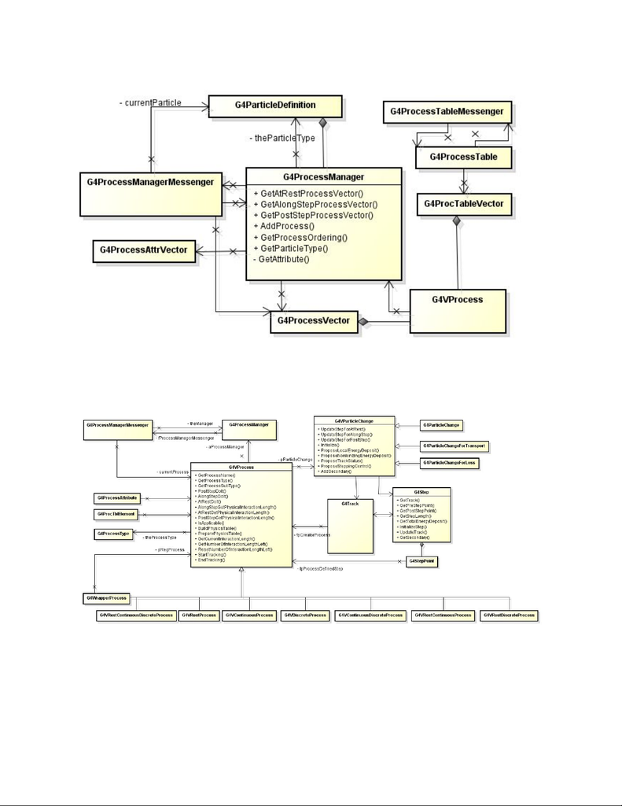

Fig. 5 Management of Physics Processes

Fig. 6 Management of Physics Processes

Electromagnetic

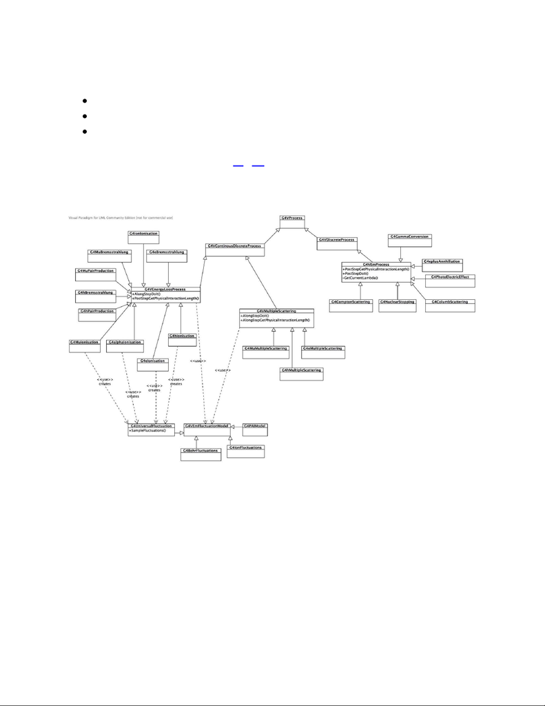

The electromagnetic (EM) processes of Geant4 follow the basic interfaces:

G4VEnergyLossProcess;

G4VEmProcess;

G4VMultipleScattering.

The class diagram is shown in Fig. 7.

Fig. 7 Design of EM physics processes.

These base classes provide all management work of initialisation of

processes, creation and filling of physics tables, and generic run-time

actions. Concrete process classes are responsible for the initialisation of

parameters and defining the set of models for the process. In some specific

cases these interfaces are not applicable and the high level interface

G4VProcess is used.

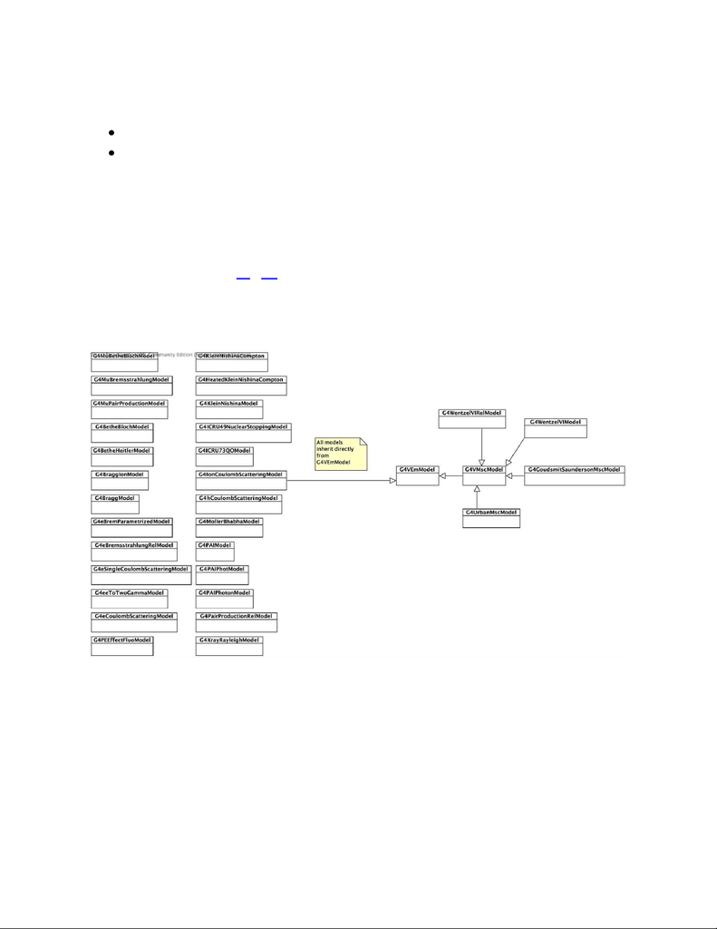

Concrete physics models are implemented via EM model interfaces:

G4VEmModel;